# Homework 3

### QUESTION 2:

> Use {ggplot} to make boxplots of each of these variables by gender.

This is for HEIGHT

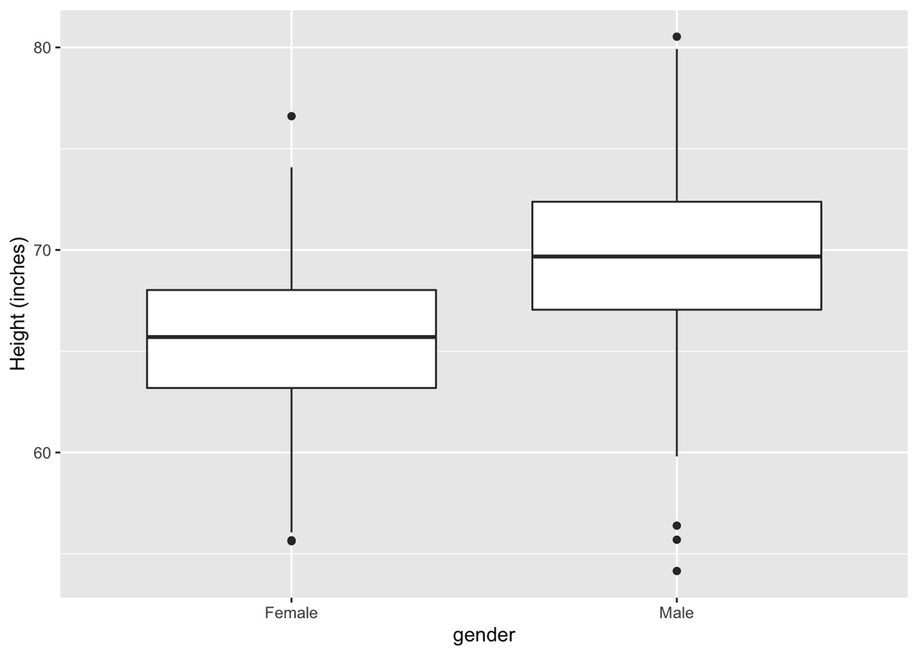

```r
library(ggplot2)
#I'm attaching the object "zombies" so that I don't have to use the $ to refer to specific variables
attach(zombies)
#First I am using ggplot2 to input the data and assign my x and y axis
height_boxplot<- ggplot(data=zombies, aes(x=gender, y=height))
#Then I use geom_boxplot to create a boxplot and add in a more specific y label
height_boxplot<- height_boxplot + geom_boxplot() + ylab("Height (inches)")
height_boxplot
```

This is for WEIGHT

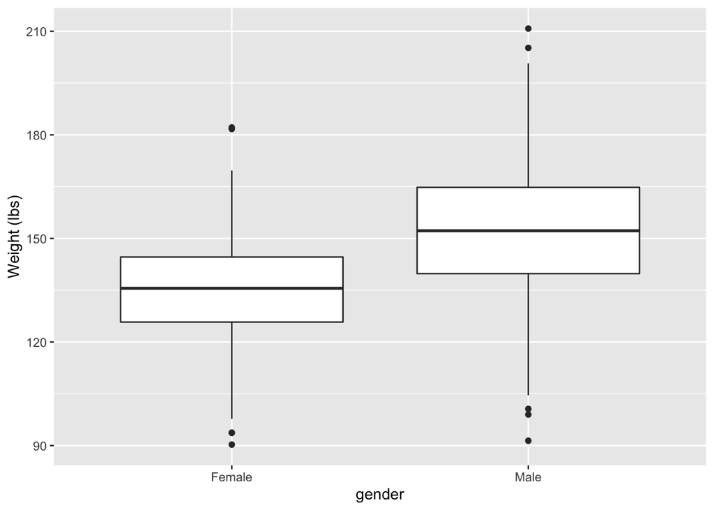

```r
#First I am using ggplot2 to input the data and assign my x and y axis
weight_boxplot<- ggplot(data=zombies, aes(x=gender, y=weight))
#Then I use geom_boxplot to create a boxplot and add in a more specific y label
weight_boxplot<- weight_boxplot + geom_boxplot() + ylab("Weight (lbs)")
weight_boxplot
```

This is for AGE

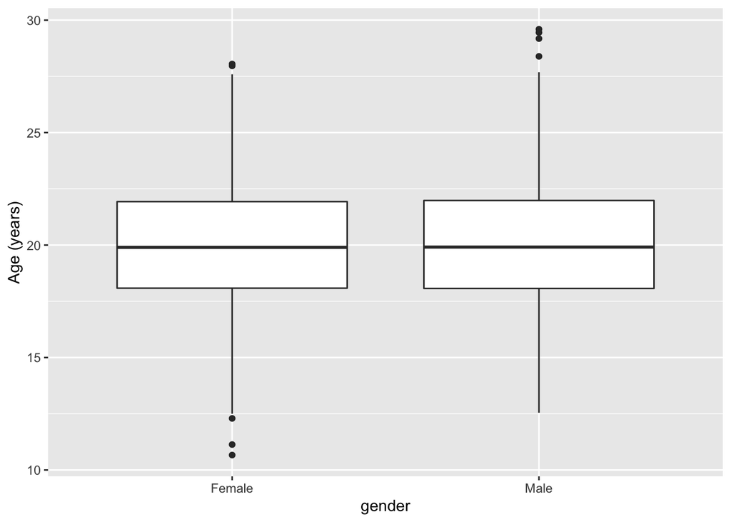

```r
#First I am using ggplot2 to input the data and assign my x and y axis
age_boxplot<- ggplot(data=zombies, aes(x=gender, y=age))
#Then I use geom_boxplot to create a boxplot and add in a more specific y label
age_boxplot<- age_boxplot + geom_boxplot() + ylab("Age (years)")
age_boxplot
```

This is for NUMBER OF ZOMBIES KILLED

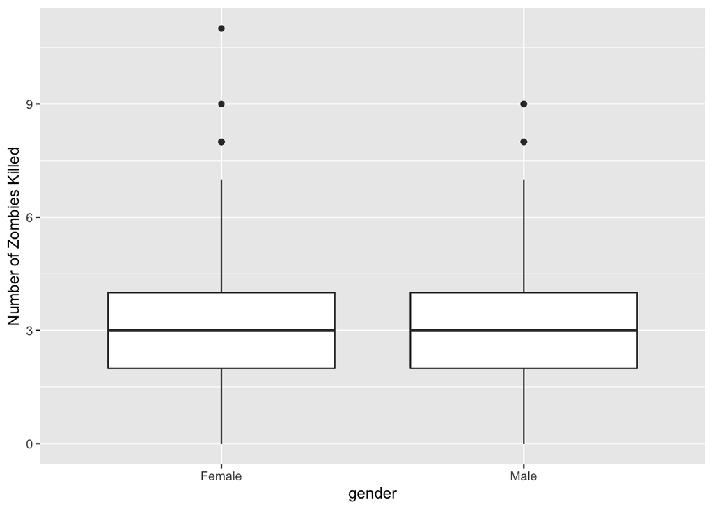

```r
#First I am using ggplot2 to input the data and assign my x and y axis
zombies_killed_boxplot<- ggplot(data=zombies, aes(x=gender, y=zombies_killed))
#Then I use geom_boxplot to create a boxplot and add in a more specific y label
zombies_killed_boxplot<- zombies_killed_boxplot + geom_boxplot() + ylab("Number of Zombies Killed")
zombies_killed_boxplot
```

This is for YEARS OF EDUCATION

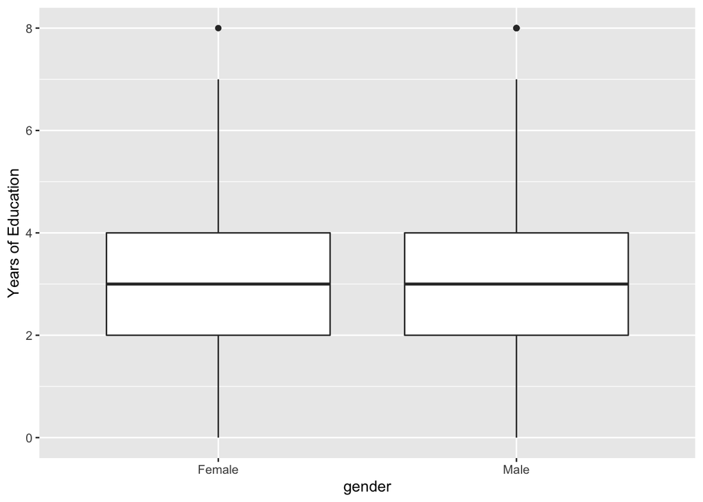

```r
#First I am using ggplot2 to input the data and assign my x and y axis
YOE_boxplot<- ggplot(data=zombies, aes(x=gender, y=YOE))
#Then I use geom_boxplot to create a boxplot and add in a more specific y label
YOE_boxplot<- YOE_boxplot + geom_boxplot() + ylab("Years of Education")
YOE_boxplot
```

### QUESTION 3:

> Use {ggplot} to make scatterplots of height and weight in relation to age. Do these variables seem to be related? In what way?

This is for HEIGHT

```r
attach(zombies)
```

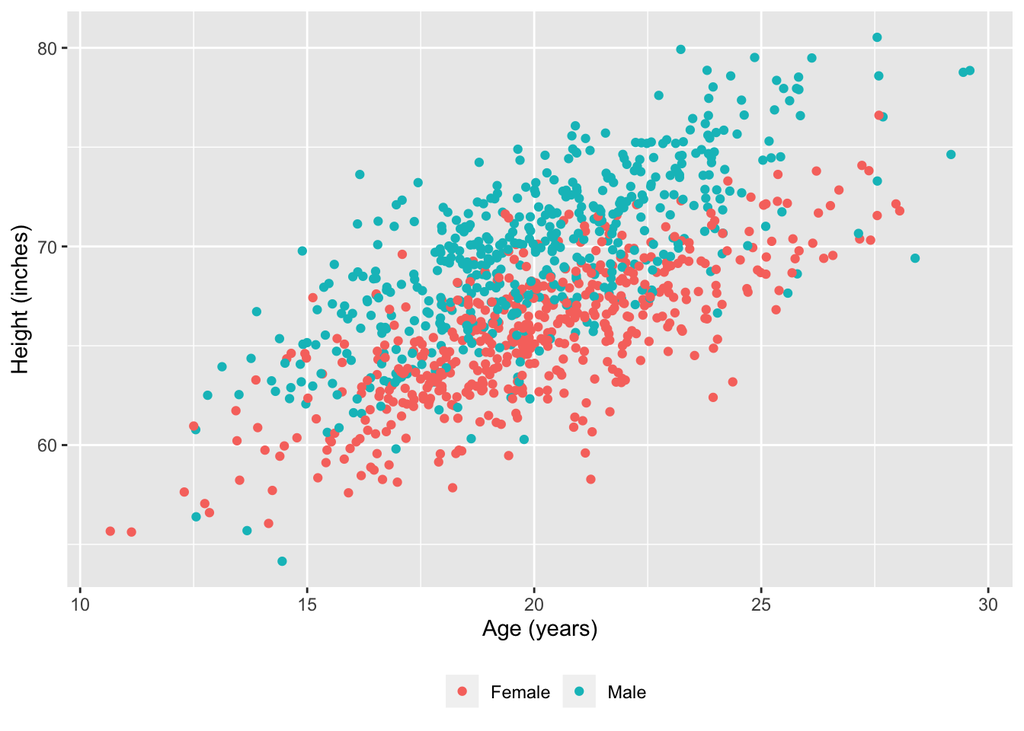

```r
library(ggplot2)
Height_age_plot <- ggplot(zombies, aes(x= age,
                        y= height,
                        color = factor(gender)
                        )) # first, we build a plot object and color points by gender (just because I                             think it will look nice)
Height_age_plot<- Height_age_plot + xlab("Age (years)") + ylab("Height (inches)") # then we modify the axis labels
Height_age_plot<- Height_age_plot + geom_point() # then we make a scatterplot
Height_age_plot <- Height_age_plot + theme(legend.position="bottom", legend.title=element_blank()) # then we modify the legend
Height_age_plot # and, finally, we plot the object
```

This is for WEIGHT

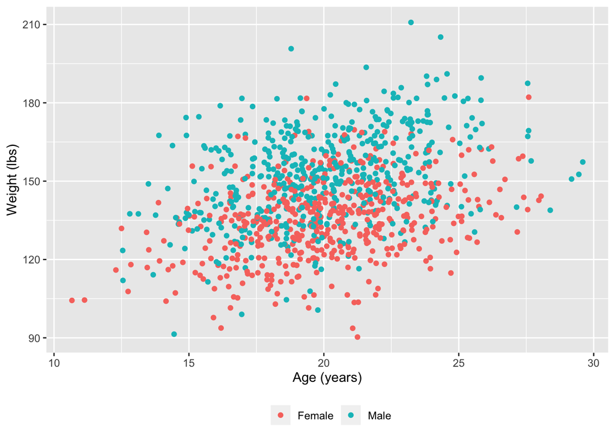

```r
Weight_age_plot <- ggplot(zombies, aes(x= age,
                        y= weight,
                        color = factor(gender)
                        )) # first, we build a plot object and color points by gender (just because I                             think it will look nice)
Weight_age_plot<- Weight_age_plot + xlab("Age (years)") + ylab("Weight (lbs)") # then we modify the axis labels
Weight_age_plot<- Weight_age_plot + geom_point() # then we make a scatterplot
Weight_age_plot <- Weight_age_plot + theme(legend.position="bottom", legend.title=element_blank()) # then we modify the legend
Weight_age_plot # and, finally, we plot the object
```

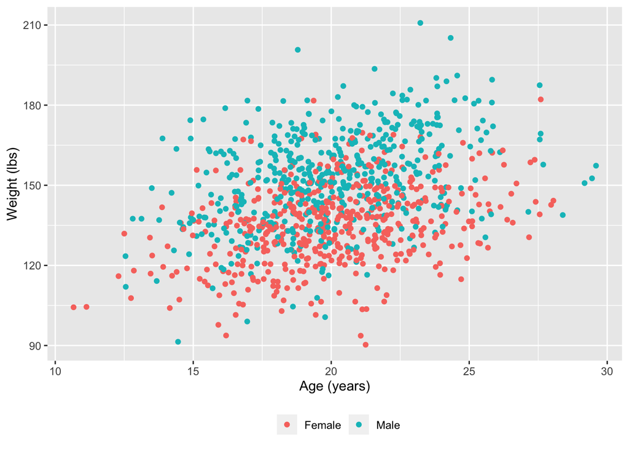

```r
par(mfrow=c(1,2)) # gives us two panels
Weight_age_plot
```

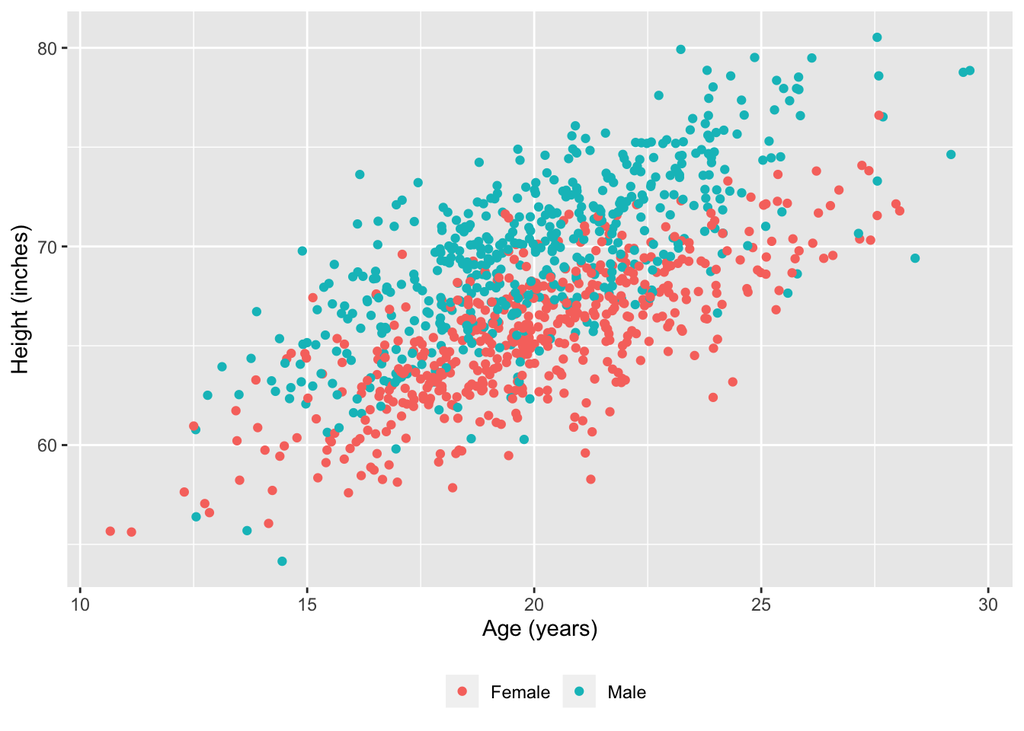

```r
Height_age_plot
```

```r
#There seems to be more of a positive correlation between age and height than between age and weight, even though you do see a slight positive relationship there as well
```

### QUESTION 4:

> Using histograms and Q-Q plots, check whether the quantitative variables seem to be drawn from a normal distribution. Which seem to be and which do not (hint: not all are drawn from the normal distribution)? For those that are not normal, can you determine from which common distribution they are drawn?

```r
attach(zombies)
```

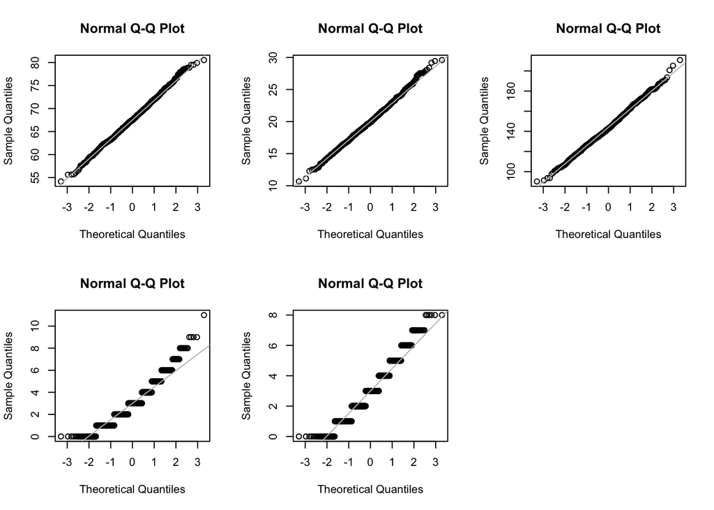

```r
par(mfrow=c(2,3)) #letting us view the data in panels

qqnorm(height)
qqline(height, col="gray")
qqnorm(age)
qqline(age, col="gray")
qqnorm(weight)
qqline(weight, col="gray")
qqnorm(zombies_killed) #Not normal distribution
qqline(zombies_killed, col="gray")
qqnorm(years_of_education) #Not normal distribution
qqline(years_of_education, col="gray")

#Now using histograms to also view the distribution,
#Setting the argument freq=FALSE will scale the Y axis to represent the proportion of observations falling into each bin rather than the count.
par(mfrow=c(2,3))
```

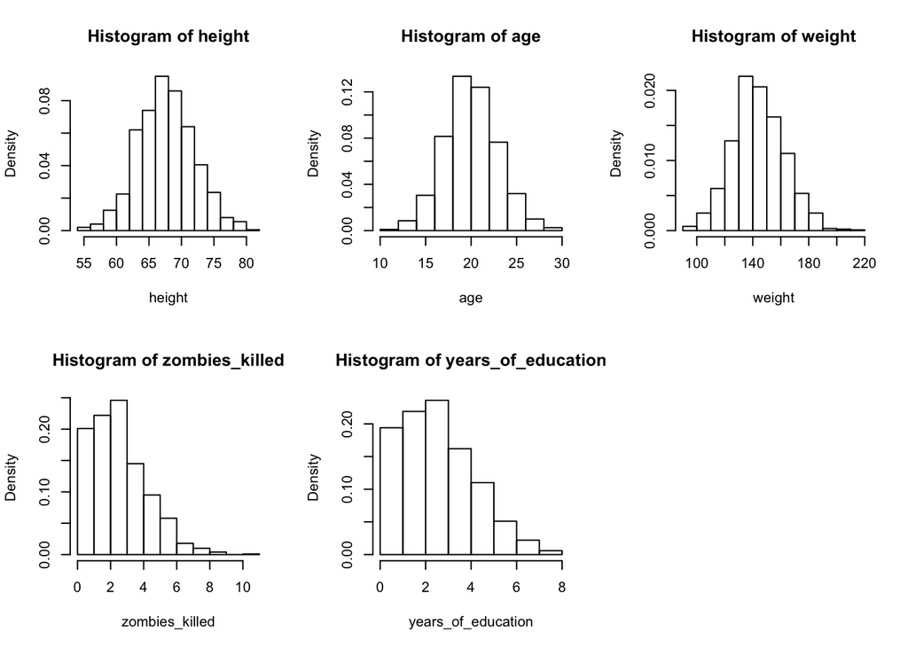

```r
hist(height, freq = FALSE)
hist(age, freq= FALSE)
hist(weight, freq = FALSE)
hist(zombies_killed, freq= FALSE) #Not a normal distribution
hist(years_of_education, freq= FALSE) #Not a normal distribution

#I think that the number of zombies killed and the years of education are drawn from a Poisson Distribution because they are both open ended counts of independently occuring events over a given period of time
```